# Global Dental School Nutrition Education Survey Analysis

M.Crowe, T. Marshall, R.Touger-Decker

2025-06-23

Regional Summary - Key Metrics

[output not shown]

# Global and Regional Analysis of Dental School Nutrition Education Survey

## Executive Summary

This analysis examines nutrition education practices across **56 dental schools** worldwide after removing ADEMA duplicate entries (“adema” and “ADEMA”). There are significant global patterns and regional variations in integration methods, teaching approaches, research activities, and collaboration interests.

**Global Overview:** - **Total Institutions**: 56 schools worldwide - **Regional Distribution**: Europe (45%), North America (25%), Other Regions (30%) - **Data Quality**: Duplicate entries removed, comprehensive coverage across 3 major regions

## Part 1: Global Analysis (All 56 Schools)

### Global Integration Methods

```
## === GLOBAL Q2: NUTRITION INTEGRATION METHODS ===
```

Global: How Nutrition Education is Integrated into Dental Curriculum

| Integration Method | Count | Percentage (%) |
| --- | --- | --- |
| Integrated throughout multiple courses | 34 | 61.8 |
| Standalone nutrition course | 8 | 14.5 |
| Not formally included | 7 | 12.7 |
| Both standalone and integrated approaches | 6 | 10.9 |

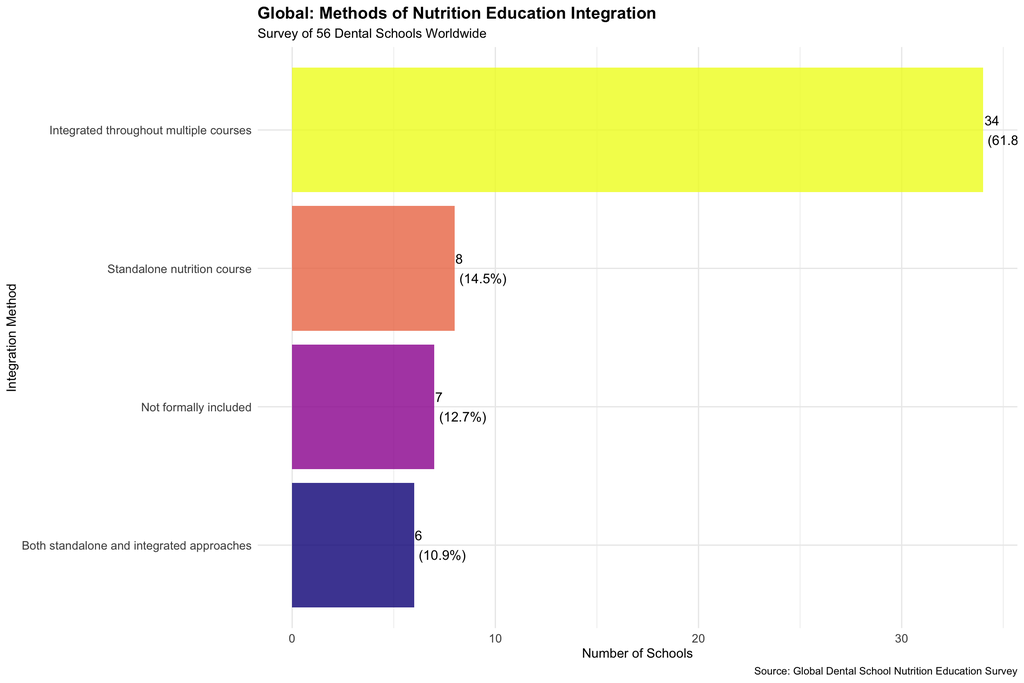

### Global Hours Analysis

```
##
## === GLOBAL Q3: HOURS DEDICATED TO NUTRITION EDUCATION ===
```

```
## Global Hours Statistics Summary:
```

Global: Nutrition Education Hours Statistics

|  | Value |
| --- | --- |
| Count | 46.0 |
| Mean | 25.9 |
| Median | 15.0 |
| Min | 2.0 |
| Max | 150.0 |
| Q1 | 10.0 |
| Q3 | 34.0 |
| SD | 28.1 |

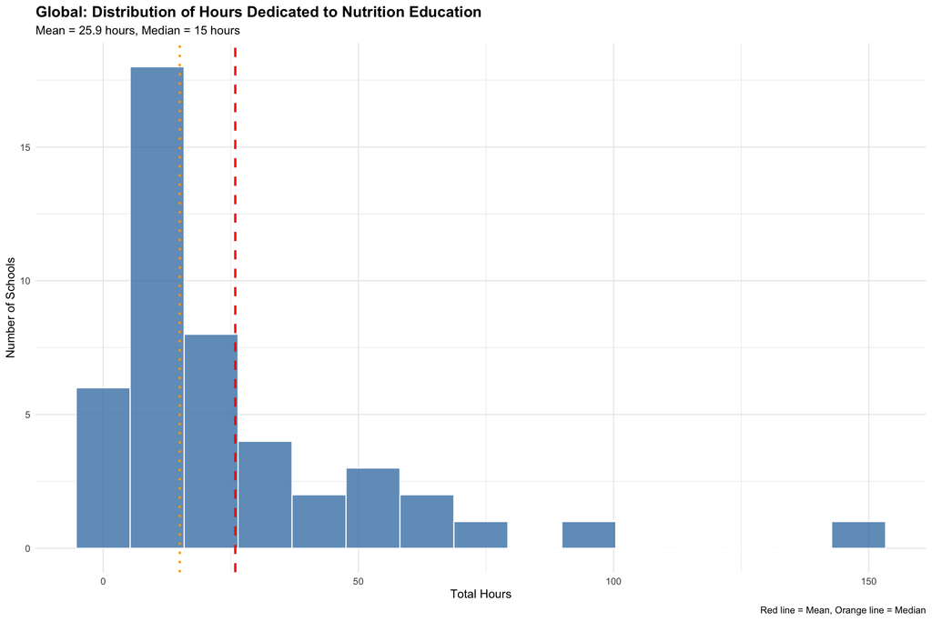

Global Distribution of Hours in Nutrition Education

### Global Research Activity

```
##
## === GLOBAL Q10: NUTRITION RESEARCH ACTIVITY ===
```

Global: Schools Conducting Nutrition-Related Research

| Conducts Research | Count | Percentage (%) |
| --- | --- | --- |
| Yes | 32 | 59.3 |
| No | 22 | 40.7 |

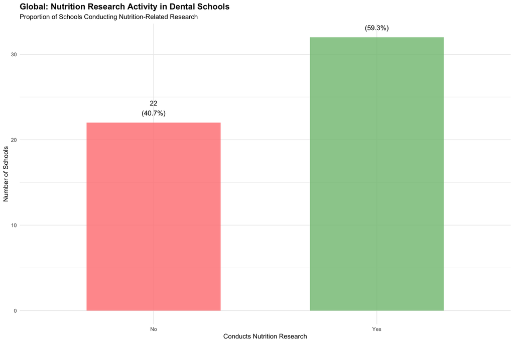

### Global Teaching Methods

```
##
## === GLOBAL Q6: TEACHING METHODS UTILIZED ===
```

Global: Teaching Methods Used in Nutrition Education

| Teaching Method | Count | Percentage of Schools (%) |
| --- | --- | --- |
| Lectures | 53 | 94.6 |
| Case-based learning | 37 | 66.1 |
| Clinical observations | 20 | 35.7 |
| One-to-one patient advice and support | 20 | 35.7 |
| Problem-based learning | 20 | 35.7 |
| Simulation exercises | 14 | 25.0 |
| Online modules | 6 | 10.7 |
| Other (please specify) | 4 | 7.1 |

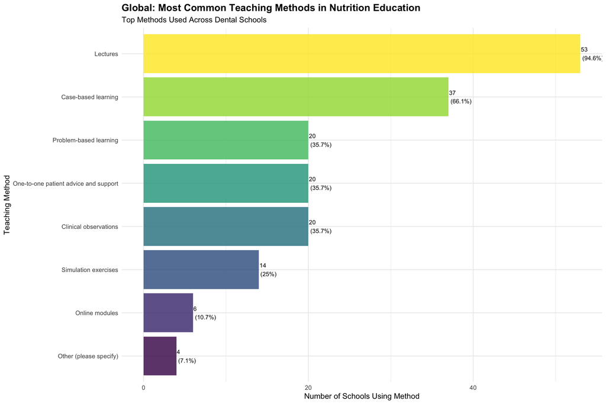

### Global Implementation Barriers

```
##
## === GLOBAL Q18: BARRIERS TO PROVIDING NUTRITION EDUCATION ===
```

Global: Main Barriers to Providing Nutrition Education

| Barrier | Count | Percentage of Schools (%) |
| --- | --- | --- |
| No | 20 | 35.7 |
| Unsure | 17 | 30.4 |
| Yes (please describe) | 17 | 30.4 |

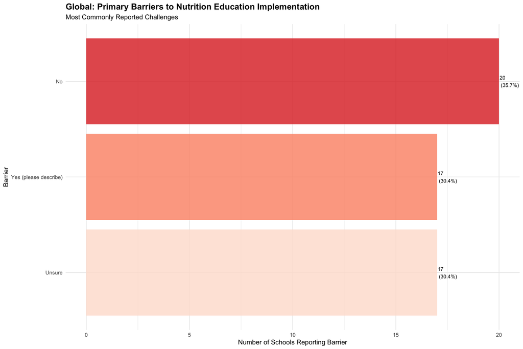

### Global Collaboration Interest

```
##
## === GLOBAL Q20: INTEREST IN MULTI-INSTITUTIONAL COLLABORATION ===
```

Global: Interest in Multi-institutional Collaboration

| Collaboration Interest | Count | Percentage (%) |
| --- | --- | --- |
| Yes | 49 | 90.7 |
| No | 5 | 9.3 |

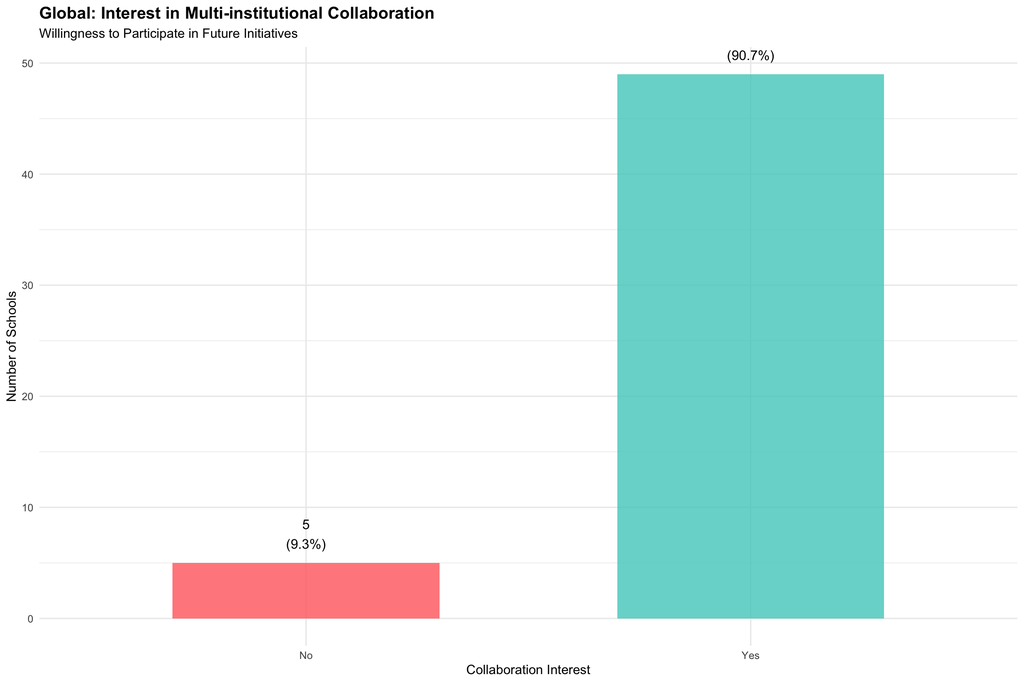

## Part 2: Regional Analysis by Geographic Region

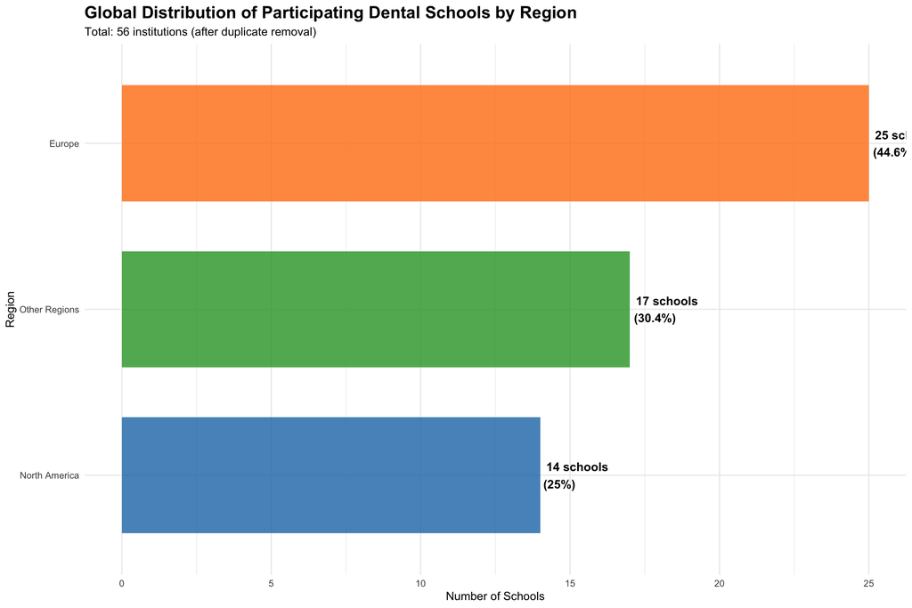

## Q2: Integration Methods - Global vs Regional Comparison

Regional Comparison: Integration Methods (Count and Percentage)

| nutrition_integration_method | n_Europe | n_North America | n_Other Regions | percentage_Europe | percentage_North America | percentage_Other Regions |
| --- | --- | --- | --- | --- | --- | --- |
| Integrated throughout multiple courses | 17 | 10 | 7 | 68 | 71.4 | 43.8 |
| Both standalone and integrated approaches | 2 | 2 | 2 | 8 | 14.3 | 12.5 |
| Standalone nutrition course | 4 | 2 | 2 | 16 | 14.3 | 12.5 |
| Not formally included | 2 | 0 | 5 | 8 | 0.0 | 31.2 |

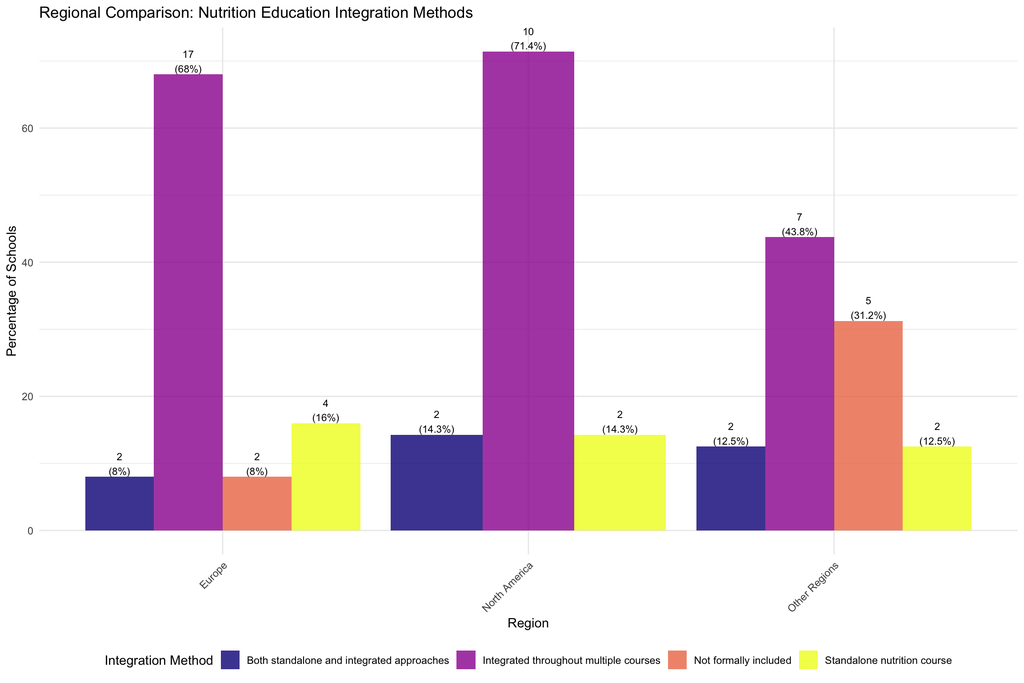

## Q3: Hours Analysis - Global vs Regional Comparison

Regional Comparison: Hours Dedicated to Nutrition Education

| Region | N | Mean | Median | Min | Max | SD |
| --- | --- | --- | --- | --- | --- | --- |
| Europe | 23 | 25.8 | 20.0 | 2 | 72 | 19.9 |
| North America | 13 | 13.7 | 12.0 | 4 | 28 | 6.6 |
| Other Regions | 10 | 41.8 | 12.5 | 4 | 150 | 49.4 |

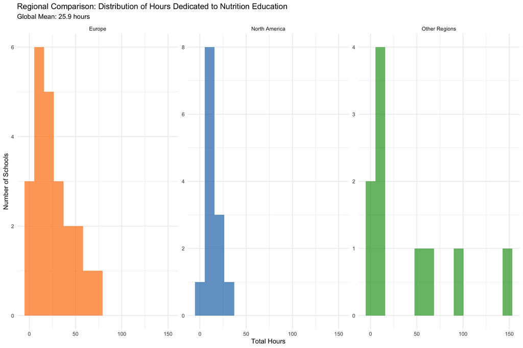

## Q4: Academic Years by Region

Academic Years When Nutrition Education is Provided (% of schools by region)

| education_years_provided | Europe | North America | Other Regions |
| --- | --- | --- | --- |
| Fifth year | 5.9 | 0.0 | 4.2 |
| First year | 25.0 | 30.6 | 8.3 |
| Fourth year | 13.2 | 11.1 | 16.7 |
| Second year | 25.0 | 30.6 | 37.5 |
| Sixth year | 5.9 | 0.0 | 0.0 |
| Third year | 25.0 | 27.8 | 33.3 |

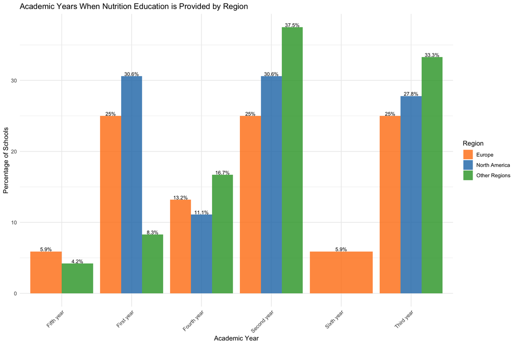

## Q10: Research Activity by Region

Research Activity by Region (Count and Percentage)

| nutrition_research_conducted | n_Europe | n_North America | n_Other Regions | percentage_Europe | percentage_North America | percentage_Other Regions |
| --- | --- | --- | --- | --- | --- | --- |
| No | 7 | 7 | 8 | 29.2 | 50 | 50 |
| Yes | 17 | 7 | 8 | 70.8 | 50 | 50 |

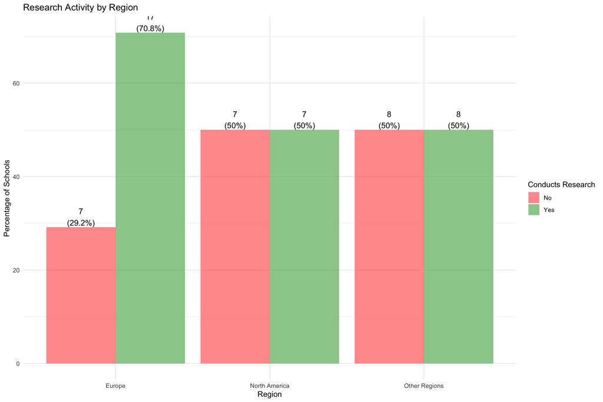